# Radon Data Exploratory Analysis

```r
library(tidyverse)
library(rbokeh)
# devtools::install_github("hafen/trelliscopejs")
library(trelliscopejs)
```

# Problem Description

Here’s the problem description from D3M:

> Radon is a carcinogen – a naturally occurring radioactive gas whose decay products are also radioactive – known to cause lung cancer in high concentrations and estimated to cause several thousand lung cancer deaths per year in the United States. The distribution of radon levels in U.S. homes varies greatly, with some houses having dangerously high concentrations. To identify areas of high radon exposure, the Environmental Protection Agency coordinated radon measurements in a random sample of houses throughout the country.

> The overall goal is to estimate the distribution of radon levels across U.S. counties, so that homeowners could make decisions about measuring or remediating the radon in their houses based on the best available knowledge of local conditions. For the purpose of this problem, we had an important predictor - whether the measurement was taken in a basement. (Radon comes from underground and can enter more easily when a house is built into the ground.) We also had an important county-level predictor - a measurement of soil uranium that was available at the county level. In this problem we’ll look at Minnesota, a state that contains 85 county’s in which different measurements are taken, ranging from 2 till 80 measurements per county. Build a model to make predictions of radon levels based on the county data and the presence of a basement.

# Data

There are two sources of data. One is from Andrew Gelman’s [hierarchical modeling book](http://www.stat.columbia.edu/~gelman/arm/) and the other from D3M. Gelman’s data has results across the United States, while the D3M data is just for Minnesota.

```r
# from Gelman
radon <- read_csv("data/ARM/srrs2.dat", na = c(".", ""))
radon
```

```
## # A tibble: 12,777 x 25
##    idnum state state2 stfips   zip region typebldg floor  room basement
##    <int> <chr>  <chr>  <int> <int>  <int>    <int> <int> <int>    <chr>
## 1      1    AZ     AZ      4 85920      1        1     1     2        N
## 2      2    AZ     AZ      4 85920      1        0     9     0     <NA>
## 3      3    AZ     AZ      4 85924      1        1     1     3        N
## 4      4    AZ     AZ      4 85925      1        1     1     3        N
## 5      5    AZ     AZ      4 85932      1        1     1     1        N
## 6      6    AZ     AZ      4 85936      1        1     1     1        N
## 7      7    AZ     AZ      4 85936      1        0     9     0     <NA>
## 8      8    AZ     AZ      4 85936      1        1     1     1        N
## 9      9    AZ     AZ      4 85938      1        0     9     0     <NA>
## 10    10    AZ     AZ      4 85938      1        1     1     3     <NA>
## # ... with 12,767 more rows, and 15 more variables: windoor <chr>,
## #   rep <int>, stratum <int>, wave <int>, starttm <chr>, stoptm <chr>,
## #   startdt <chr>, stopdt <chr>, activity <dbl>, pcterr <dbl>,
## #   adjwt <dbl>, dupflag <int>, zipflag <int>, cntyfips <int>,
## #   county <chr>
```

```r
# from D3M
radon_mn <- read_csv("data/r_26/raw_data/radon.csv")
radon_mn
```

```
## # A tibble: 919 x 28
##    radonFile_index state state2 stfips   zip region typebldg floor  room
##              <int> <chr>  <chr>  <dbl> <int>  <dbl>    <dbl> <dbl> <dbl>
## 1             5081    MN     MN     27 55735      5        1     1     3
## 2             5082    MN     MN     27 55748      5        1     0     4
## 3             5083    MN     MN     27 55748      5        1     0     4
## 4             5084    MN     MN     27 56469      5        1     0     4
## 5             5085    MN     MN     27 55011      3        1     0     4
## 6             5086    MN     MN     27 55014      3        1     0     4
## 7             5087    MN     MN     27 55014      3        1     0     4
## 8             5088    MN     MN     27 55014      3        1     0     2
## 9             5089    MN     MN     27 55014      3        1     0     4
## 10            5090    MN     MN     27 55014      3        1     0     4
## # ... with 909 more rows, and 19 more variables: basement <chr>,
## #   windoor <chr>, rep <int>, stratum <dbl>, wave <int>, starttm <dbl>,
## #   stoptm <dbl>, startdt <dbl>, stopdt <dbl>, activity <dbl>,
## #   pcterr <dbl>, adjwt <dbl>, dupflag <dbl>, zipflag <dbl>,
## #   cntyfips <dbl>, county <chr>, fips <dbl>, Uppm <dbl>,
## #   county_code <int>
```

```r
# how do these datasets differ in terms of variables?
setdiff(names(radon), names(radon_mn))
```

```
## [1] "idnum"
```

```r
setdiff(names(radon_mn), names(radon))
```

```
## [1] "radonFile_index" "fips"            "Uppm"            "county_code"
```

I haven’t found a data dictionary for these. The D3M schema doesn’t provide any information about the variables.

Here’s a summary of each of the variables:

```r
summary(radon)
```

```
##      idnum          state              state2              stfips
##  Min.   :    1   Length:12777       Length:12777       Min.   : 4.00
##  1st Qu.: 3195   Class :character   Class :character   1st Qu.:18.00
##  Median : 6389   Mode  :character   Mode  :character   Median :27.00
##  Mean   : 6389                                         Mean   :28.14
##  3rd Qu.: 9583                                         3rd Qu.:38.00
##  Max.   :12777                                         Max.   :55.00
##
##       zip            region          typebldg         floor
##  Min.   : 1001   Min.   : 1.000   Min.   :0.000   Min.   :0.000
##  1st Qu.:17756   1st Qu.: 2.000   1st Qu.:1.000   1st Qu.:0.000
##  Median :54155   Median : 3.000   Median :1.000   Median :0.000
##  Mean   :45125   Mean   : 3.768   Mean   :1.038   Mean   :0.522
##  3rd Qu.:63090   3rd Qu.: 5.000   3rd Qu.:1.000   3rd Qu.:1.000
##  Max.   :86512   Max.   :11.000   Max.   :5.000   Max.   :9.000
##  NA's   :1
##       room         basement           windoor               rep
##  Min.   :0.000   Length:12777       Length:12777       Min.   :1.000
##  1st Qu.:2.000   Class :character   Class :character   1st Qu.:2.000
##  Median :3.000   Mode  :character   Mode  :character   Median :3.000
##  Mean   :3.026                                         Mean   :3.009
##  3rd Qu.:4.000                                         3rd Qu.:4.000
##  Max.   :7.000                                         Max.   :5.000
##                                                        NA's   :934
##     stratum            wave          starttm             stoptm
##  Min.   : 1.000   Min.   :  1.00   Length:12777       Length:12777
##  1st Qu.: 2.000   1st Qu.: 34.00   Class :character   Class :character
##  Median : 2.000   Median : 56.00   Mode  :character   Mode  :character
##  Mean   : 3.415   Mean   : 59.09
##  3rd Qu.: 4.000   3rd Qu.: 82.00
##  Max.   :29.000   Max.   :140.00
##                   NA's   :934
##    startdt             stopdt             activity          pcterr
##  Length:12777       Length:12777       Min.   :  0.00   Min.   :  0.00
##  Class :character   Class :character   1st Qu.:  1.10   1st Qu.:  5.20
##  Mode  :character   Mode  :character   Median :  2.30   Median :  9.90
##                                        Mean   :  4.48   Mean   : 13.46
##                                        3rd Qu.:  4.80   3rd Qu.: 18.40
##                                        Max.   :273.50   Max.   :490.40
##
##      adjwt             dupflag           zipflag             cntyfips
##  Min.   :   2.082   Min.   :0.00000   Min.   :0.0000000   Min.   :  1.00
##  1st Qu.: 218.513   1st Qu.:0.00000   1st Qu.:0.0000000   1st Qu.: 17.00
##  Median : 443.844   Median :0.00000   Median :0.0000000   Median : 47.00
##  Mean   : 540.962   Mean   :0.03921   Mean   :0.0008609   Mean   : 81.78
##  3rd Qu.: 675.416   3rd Qu.:0.00000   3rd Qu.:0.0000000   3rd Qu.: 97.00
##  Max.   :2364.763   Max.   :2.00000   Max.   :1.0000000   Max.   :999.00
##
##     county
##  Length:12777
##  Class :character
##  Mode  :character
##
##
##
##
```

The data from Gelman also provides geographical coordinates for the counties:

```r
geo <- read_csv("data/ARM/cty.dat")
geo
```

```
## # A tibble: 3,194 x 7
##    stfips ctfips    st      cty     lon    lat    Uppm
##     <chr>  <chr> <chr>    <chr>   <dbl>  <dbl>   <dbl>
## 1      01    001    AL  AUTAUGA -86.643 32.534 1.78331
## 2      01    003    AL  BALDWIN -87.750 30.661 1.38323
## 3      01    005    AL  BARBOUR -85.393 31.870 2.10105
## 4      01    007    AL     BIBB -87.126 32.998 1.67313
## 5      01    009    AL   BLOUNT -86.568 33.981 1.88501
## 6      01    011    AL  BULLOCK -85.716 32.100 2.46112
## 7      01    013    AL   BUTLER -86.680 31.752 1.91714
## 8      01    015    AL  CALHOUN -85.827 33.772 1.97532
## 9      01    017    AL CHAMBERS -85.392 32.914 1.75695
## 10     01    019    AL CHEROKEE -85.604 34.176 1.76798
## # ... with 3,184 more rows
```

# Exploration

## Response variable: activity

Let’s look at the response variable `activity`. From the summary above, we see that it is non-negative. A quick look at its distribution:

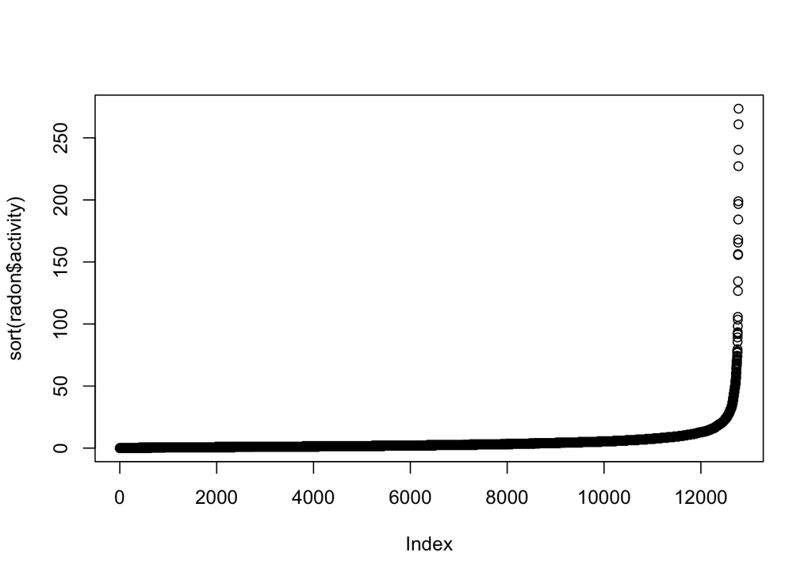

```r
plot(sort(radon$activity))
```

It looks very heavy-tailed so we probably want to look into a log transformation. But there are zero-valued observations. Also, are there any missing values?

```r
length(which(is.na(radon$activity)))
```

```
## [1] 0
```

No missing values. Let’s see how many zero-valued observations there are:

```r
length(which(radon$activity == 0))
```

```
## [1] 90
```

Not many. What’s the lowest non-zero value we observe?

```r
min(radon$activity[radon$activity > 0])
```

```
## [1] 0.1
```

Let’s create a log activity variable and deal with zeros by setting them to the lowest-observed non-zero value.

```r
radon$log_activity <- log2(ifelse(radon$activity == 0, 0.1, radon$activity))
```

Now let’s look at the distribution of this variable:

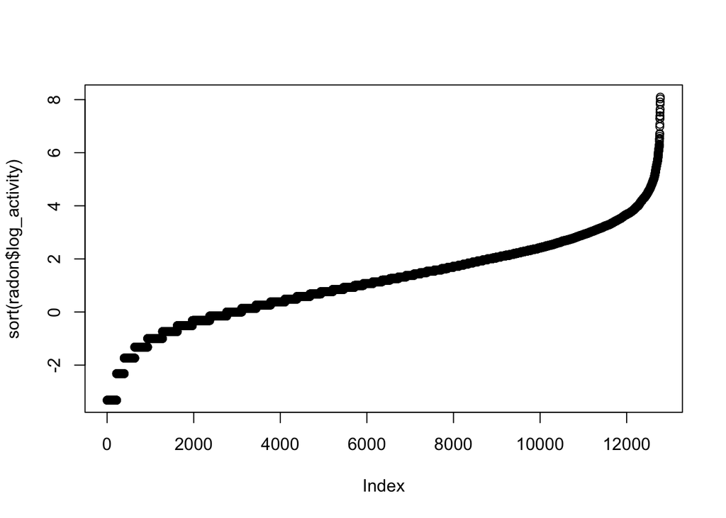

```r
plot(sort(radon$log_activity))
```

This looks better. It may even look normally distributed. Let’s check:

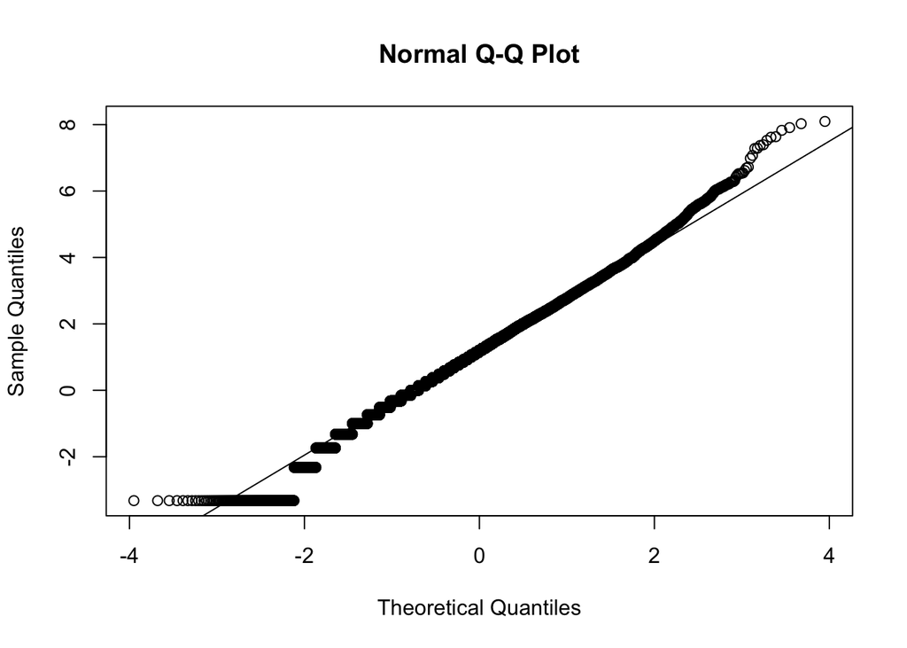

```r
qqnorm(radon$log_activity)
qqline(radon$log_activity)
```

We’ll use this variable in our modeling.

## Other covariates

Here are some exploratory visualizations of some of the other covariates.

Some of these variables, while they look like numeric, are treated better as categorical, so we’ll change their type before plotting:

```r
radon$room <- as.character(radon$room)
radon$floor <- as.character(radon$floor)
radon$typebldg <- as.character(radon$typebldg)
```

### wave

I don’t know what the `wave` variable is. It’s numeric so let’s look at its distribution.

```r
figure(data = radon) %>% ly_quantile(wave)
```

[interactive chart not shown]

```r
figure(data = radon) %>% ly_hist(wave)
```

[interactive chart not shown]

The distribution has two modes…

### room

```r
figure(data = radon) %>% ly_bar(room, hover = TRUE)
```

[interactive chart not shown]

Strange that there aren’t many observed room values of 5 and 6 when there’s a significant amount of 7.

### floor

```r
figure(data = radon) %>% ly_bar(floor, hover = TRUE)
```

[interactive chart not shown]

Why is there a floor 9 but nothing between 3 and 9?

### typebldg

```r
figure(data = radon) %>% ly_bar(typebldg, hover = TRUE)
```

[interactive chart not shown]

I don’t know what this is, but 1 is the most prominent (maybe that’s residential?).

### basement

```r
figure(data = radon) %>% ly_bar(basement, hover = TRUE)
```

[interactive chart not shown]

I wonder what “0” means…

### Variable combinations

```r
figure(data = radon) %>% ly_bar(room, color = basement, hover = TRUE)
```

[interactive chart not shown]

```r
figure(data = radon) %>% ly_bar(room, color = basement, hover = TRUE, position = "fill")
```

[interactive chart not shown]

```r
figure(data = radon) %>% ly_bar(typebldg, color = room, hover = TRUE, position = "fill")
```

[interactive chart not shown]